# Data Quality

Data

Python

In the following article you will find the definition of data quality, what the domains are and how to quickly implement a solution.

Romina Mendez https://r0mymendez.github.io/romymendezblog/  
11-12-2023

[figure not shown]

In the current digital environment, the amount of available data is overwhelming. However, the true cornerstone for making informed decisions lies in the quality of this data. In this article, we will explore the crucial importance of data quality, analyzing the inherent challenges that organizations face in managing information. Although often overlooked, data quality plays a fundamental role in the reliability and usefulness of the information that underpins our strategic decisions.

# What is `Data quality`?

Data quality measures how well a dataset complies with the criteria of accuracy, completeness, validity, consistency, uniqueness, timeliness, and fitness for purpose, and is fundamental for all data governance initiatives within an organization. Data quality standards ensure that companies make decisions based on data to achieve their business objectives.

source: [IBM](https://www.ibm.com/topics/data-quality)

[figure not shown]

source: [DataCamp cheat sheet](https://www.datacamp.com/cheat-sheet/data-quality-dimensions-cheat-sheet)

The following table highlights the various domains of data quality, from accuracy to fitness, providing an essential guide for assessing and enhancing the robustness of datasets:

| **Dimensions** | **Description** |
| --- | --- |
| **🎯 Accuracy** | Data accuracy, or how close data is to reality or truth. Accurate data is that which faithfully reflects the information it seeks to represent. |
| **🧩 Completeness** | Measures the entirety of the data. A complete dataset is one that has no missing values or significant gaps. Data integrity is crucial for gaining a comprehensive and accurate understanding. |
| **✅ Validity** | Indicates whether the data conforms to defined rules and standards. Valid data complies with the established constraints and criteria for a specific dataset.. |
| **🔄 Consistency** | Refers to the uniformity of data over time and across different datasets. Consistent data does not exhibit contradictions or discrepancies when compared with each other |
| **📇 Uniqueness** | Evaluates whether there are no duplicates in the data. Unique data ensures that each entity or element is represented only once in a dataset |
| **⌛Timeliness** | Refers to the timeliness of data. Timely information is that which is available when needed, without unnecessary delays. |
| **🏋️ Fitness** | This aspect evaluates the relevance and usefulness of data for the intended purpose. Data should be suitable and applicable to the specific objectives of the organization or analysis being conducted. |

# Data quality dimensions - Use case

Next, we provide an example where some issues with an e-commerce-based use case can be observed.

| **ID Transacción** | **ID Cliente** | **Producto** | **Cantidad** | **Precio Unitario** | **Total** |
| --- | --- | --- | --- | --- | --- |
| ⚪ 1 | 10234 | Laptop HP | 1 | $800 | $800 |
| 🟣 2 |  | Wireless Headphones | 2 | $50 | $100 |
| 🔵 3 | 10235 | Smartphone | -1 | $1000 | -$1000 |
| 🟢 4 | 10236 | Wireless Mouse | 3 | $30 | $90 |
| 🟢 4 | 10237 | Wireless Keyboard | 2 | $40 | $80 |

- 🟣 **Row 2 (Completeness)**: Row 2 does not comply with data integrity (Completeness) as the customer ID is missing. Customer information is incomplete, making it challenging to trace the transaction back to a specific customer.
- 🔵 **Row 3 (Accuracy and Consistency)**: Row 3 exhibits accuracy (Accuracy) and consistency (Consistency) issues. The quantity of products is negative, which is inaccurate and goes against the expected consistency in a transaction dataset.
- 🟢 **Row 4 (Uniqueness):** The introduction of a second row with the same transaction ID (Transaction ID = 4) violates the uniqueness principle. Each transaction should have a unique identifier, and having two rows with the same Transaction ID creates duplicates, affecting the uniqueness of transactions.

# Python Frameworks

The following are some of the Python implementations carried out to perform data quality validations:

| **Framework** | **Descripción** |
| --- | --- |
| [**Great Expectations**](https://github.com/great-expectations/great_expectations) | Great Expectations is an open-source library for data validation. It enables the definition, documentation, and validation of expectations about data, ensuring quality and consistency in data science … |
| [**Pandera**](https://github.com/unionai-oss/pandera) | Pandera is a data validation library for data structures in Python, specifically designed to work with pandas DataFrames. It allows you to define schemas and validation rules to ensure data conformity |
| [**Dora**](https://github.com/NathanEpstein/Dora) | Dora is a Python library designed to automate data exploration and perform exploratory data analysis. |

Let’s analyze some of the metrics that can be observed in their GitHub repositories, taking into account that the metrics were obtained on 2023-11-12.

Metricas

[**Great Expectations**](https://github.com/great-expectations/great_expectations)

[**Pandera**](https://github.com/unionai-oss/pandera)

[**Dora**](https://github.com/NathanEpstein/Dora)

👥 Members

399

109

106

⚠️ Issues: Open

112

273

1

🟢 Issues: Close

1642

419

7

⭐ Stars

9000

2700

623

📺 Watching

78

17

42

🔎 Forks

1400

226

63

📬 Open PR

43

19

0

🐍 Version Python

>=3.8

>=3.7

No especificada

📄 Version Number

233

76

3

📄 Last Version

0.18.2

0.17.2

0.0.3

📆 Last Date Version

9 Nov 2023

30 sep 2023

30 jun 2020

📄 Licence type

Apache-2.0 license

MIT

MIT

📄 Languages

- Python 95.1%
- Jupyter Notebook 4.3%
- Jinja 0.4%
- JavaScript 0.1%
- CSS 0.1%
- HTML 0.0%
- Python 99.9%
- Makefile 0.1%
- Python100%

## Differences between Licencia Apache 2.0 y MIT

- **Notification of Changes:**
  - **Apache 2.0:** Requires notification of changes made to the source code when distributing the software.
  - **MIT:** Does not require specific notification of changes.
- **Compatibility:**
  - **Apache 2.0:** Known to be compatible with more licenses compared to MIT.
  - **MIT:** Also quite compatible with various licenses, but Apache 2.0 License is often chosen in projects seeking greater interoperability with other licenses.
- **Attribution:**
  - **Apache 2.0:** Requires attribution and the inclusion of a copyright notice.
  - **MIT:** Requires attribution to the original authorship but may have less strict requirements in terms of how that attribution is displayed.

  > Considering these currently analyzed metrics, let’s proceed with an example implementation using Pandera and Great Expectations.

## Dataset

For the development of this example, we will use the dataset named ‘Tips.’ You can download the dataset from the followinge [link](https://raw.githubusercontent.com/mwaskom/seaborn-data/master/tips.csv).

The ‘tips’ dataset contains information about tips given in a restaurant, along with details about the total bill, the gender of the person who paid the bill, whether the customer is a smoker, the day of the week, and the meal’s time.

| Column | Description |
| --- | --- |
| total_bill | The total amount of the bill (including the tip). |
| tip | The amount of tip given. |
| sex | The gender of the bill payer (male or female). |
| smoker | Whether the customer is a smoker or not. |
| day | The day of the week when the meal was made. |
| time | The time of day (lunch or dinner). |
| size | The size of the group that shared the meal. |

Below is a table with the first 5 rows of the dataset:

| total_bill | tip | sex | smoker | day | time | size |
| --- | --- | --- | --- | --- | --- | --- |
| 16.99 | 1.01 | Female | No | Sun | Dinner | 2 |
| 10.34 | 1.66 | Male | No | Sun | Dinner | 3 |
| 21.01 | 3.50 | Male | No | Sun | Dinner | 3 |
| 23.68 | 3.31 | Male | No | Sun | Dinner | 2 |
| 24.59 | 3.61 | Female | No | Sun | Dinner | 4 |

## 🟢 Pandera

Next, we will provide an example of implementing Pandera using the dataset described earlier.

### Install pandera

```bash
pip install pandas pandera
```

### Implementation Example

1. Import pandas and pandera

   ```python
   import pandas as pd
   import pandera as pa
   ```

2. Import the dataframe file

   ```python
   path = 'data/tips.csv'
   data = pd.read_csv(path)

   print(f"Numero de columnas: {data.shape[1]}, Numero de filas: {data.shape[0]}")
   print(f"Nombre de columnas: {list(data.columns)}")
   ```

   ```python
   data.info()
   ```

   ```bash
   <class 'pandas.core.frame.DataFrame'>
   RangeIndex: 244 entries, 0 to 243
   Data columns (total 7 columns):
    #   Column      Non-Null Count  Dtype
   ---  ------      --------------  -----
    0   total_bill  244 non-null    float64
    1   tip         244 non-null    float64
    2   sex         244 non-null    object
    3   smoker      244 non-null    object
    4   day         244 non-null    object
    5   time        244 non-null    object
    6   size        244 non-null    int64
   dtypes: float64(2), int64(1), object(4)
   memory usage: 13.5+ KB
   ```

3. Now, let’s create the schema object that contains all the validations we want to perform.

   You can find additional validations that can be performed at the following link: [<https://pandera.readthedocs.io/en/stable/dtype_validation.html>](https://pandera.readthedocs.io/en/stable/dtype_validation.html)

```python
schema = pa.DataFrameSchema({
  "total_bill": pa.Column(float, checks=pa.Check.le(50)),
  "tip"       : pa.Column(float, checks=pa.Check.between(0,30)),
  "sex"       : pa.Column(str, checks=[pa.Check.isin(['Female','Male'])]),
  "smoker"    : pa.Column(str, checks=[pa.Check.isin(['No','Yes'])]),
  "day"       : pa.Column(str, checks=[pa.Check.isin(['Sun','Sat'])]),
  "time"      : pa.Column(str, checks=[pa.Check.isin(['Dinner','Lunch'])]),
  "size"      : pa.Column(int, checks=[pa.Check.between(1,4)])
})
```

4. To capture the error and subsequently analyze the output, it is necessary to catch it using an exception.

```python
try:
    schema(data).validate()
except Exception as e:
    print(e)
    error = e
```

```bash
Schema None: A total of 3 schema errors were found.

Error Counts
------------
- SchemaErrorReason.SCHEMA_COMPONENT_CHECK: 3

Schema Error Summary
--------------------
schema_context column     check                     failure_cases  n_failure_cases

Column         day        isin(['Sun', 'Sat'])      [Thur, Fri]             2
               size       in_range(1, 4)              [5, 6]                2
               total_bill less_than_or_equal_to(50)   [50.81]               1
```

5. Below is a function that allows you to transform the output into a dictionary or a pandas dataframe

```python
def get_errors(error, dtype_dict=True):
    response = []


    for item in range(len(error.schema_errors)):
        error_item = error.schema_errors[item]
        response.append(
        {
            'column'     :error_item.schema.name,
            'check_error':error_item.schema.checks[0].error,
            'num_cases'  :error_item.failure_cases.index.shape[0],
            'check_rows' :error_item.failure_cases.to_dict()
        })

    if dtype_dict:
        return response
    else:
        return pd.DataFrame(response)
```

```python
get_errors(error,dtype_dict=True)
```

```bash
[{'column': 'total_bill',
  'check_error': 'less_than_or_equal_to(50)',
  'num_cases': 1,
  'check_rows': {'index': {0: 170}, 'failure_case': {0: 50.81}}},
 {'column': 'day',
  'check_error': "isin(['Sun', 'Sat'])",
  'num_cases': 81,
  'check_rows': {'index': {0: 77,
    1: 78,
    2: 79,
    3: 80,
    4: 81,
    5: 82,
    6: 83,
    7: 84,
...
    5: 156,
    6: 185,
    7: 187,
    8: 216},
   'failure_case': {0: 6, 1: 6, 2: 5, 3: 6, 4: 5, 5: 6, 6: 5, 7: 5, 8: 5}}}]
```

## 🟠 Great Expectations

Great Expectations is an open-source Python-based library for validating, documenting, and profiling your data. It helps maintain data quality and improve communication about data across teams.

[figure not shown]

source : [<https://docs.greatexpectations.io/docs/>](https://docs.greatexpectations.io/docs/)

Therefore, we can describe Great Expectations as an open source tool designed to guarantee the quality and reliability of data in various sources, such as databases, tables, files and dataframes. Its operation is based on the creation of validation groups that specify the expectations or rules that the data must comply with.

The following are the steps that we must define when using this framework:

1. **Definition of Expectations:** Specify the expectations you have for the data. These expectations can include simple constraints, such as value ranges, or more complex rules about data coherence and quality.
2. **Connecting to Data Sources:** In this step, define the connections you need to make to various data sources, such as databases, tables, files, or dataframes.
3. **Generation of Validation Suites:** Based on the defined expectations, Great Expectations generates validation suites, which are organized sets of rules to be applied to the data.
4. **Execution of Validations:** Validation suites are applied to the data to verify if they meet the defined expectations. This can be done automatically in a scheduled workflow or interactively as needed.
5. **Generation of Analysis and Reports:** Great Expectations provides advanced analysis and reporting capabilities. This includes detailed data quality profiles and reports summarizing the overall health of the data based on expectations.
6. **Alerts and Notifications:** If the data does not meet the defined expectations, Great Expectations can generate alerts or notifications, allowing users to take immediate action to address data quality issues.

Together, Great Expectations offers a comprehensive solution to ensure data quality over time, facilitating early detection of problems and providing confidence in the integrity and usefulness of data used in analysis and decision-making

### Install great expectation

```python
!pip install great_expectations==0.17.22 seaborn matplotlib numpy pandas
```

### Implementation example

```
import pandas as pd
import numpy as np
import seaborn as sns
import matplotlib.pyplot as plt
import os
import re

import great_expectations as gx
from ruamel.yaml import YAML
from great_expectations.cli.datasource import sanitize_yaml_and_save_datasource
from great_expectations.core.expectation_configuration import ExpectationConfiguration

print(f"* great expectations version:{gx.__version__}")
print(f"* seaborn version:{sns.__version__}")
print(f"* numpy version:{np.__version__}")
print(f"* pandas:{pd.__version__}")
```

```bash
* great expectations version:0.17.22
* seaborn version:0.13.0
* numpy version:1.26.1
* pandas:2.1.3
```

1. Import dataset using great expectation

```python
path = 'data/tips.csv'
data_gx = gx.read_csv(path)
```

2. List all available expectations by type

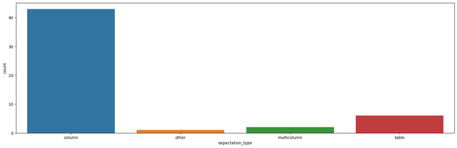

```python
list_expectations = pd.DataFrame([item for item in dir(data_gx) if item.find('expect_')==0],columns=['expectation'])
list_expectations['expectation_type'] = np.select( [
        list_expectations.expectation.str.find('_table_')>0,
        list_expectations.expectation.str.find('_column_')>0,
        list_expectations.expectation.str.find('_multicolumn_')>0,
    ],['table','column','multicolumn'],
    default='other'
)

plt.figure(figsize=(20,6))
sns.countplot(x=list_expectations.expectation_type)
plt.show()
```

> In the image, it can be observed that the available expectations are mainly applied to columns (for example: **`expect_column_max_to_be_between`**) and tables (for example: **`expect_table_columns_to_match_set`**), although an expectation based on the values of multiple columns can also be applied (for example: **`expect_multicolumn_values_to_be_unique`**).

#### Expectations: Tables

```python
# The following list contains the columns that the dataframe must have:
columns = ['total_bill', 'tip', 'sex', 'smoker', 'day', 'time', 'size']
data_gx.expect_table_columns_to_match_set(column_set = columns)
```

```bash
{
  "success": true,
  "result": {
    "observed_value": [
      "total_bill",
      "tip",
      "sex",
      "smoker",
      "day",
      "time",
      "size"
    ]
  },
  "meta": {},
  "exception_info": {
    "raised_exception": false,
    "exception_traceback": null,
    "exception_message": null
  }
}
```

```python
# Now, we delete two columns, 'time' and 'size,' to validate the outcome

columns = = ['total_bill', 'tip', 'sex', 'smoker', 'day']
data_gx.expect_table_columns_to_match_set(column_set = columns)
```

If we observe, the result is False, and in the details, they provide information about the columns that the dataframe has in addition to those expected.

```python
{
  "success": false,
  "result": {
    "observed_value": [
      "day",
      "sex",
      "size",
      "smoker",
      "time",
      "tip",
      "total_bill"
    ],
    "details": {
      "mismatched": {
        "unexpected": [
          "size",
          "time"
        ]
      }
    }
  },
  "meta": {},
  "exception_info": {
    "raised_exception": false,
    "exception_traceback": null,
    "exception_message": null
  }
}
```

#### Expectations: Columns

1. Let’s validate that there is a categorical value within a column

```python
data_gx['total_bill_group'] = pd.cut(data_gx['total_bill'],
                              bins=[0,10,20,30,40,50,float('inf')],
                              labels=['0-10', '10-20', '20-30', '30-40', '40-50', '>50'],
                              right=False,
                              include_lowest=True)

# Now, let's validate if 3 categories exist within the dataset

data_gx.expect_column_distinct_values_to_contain_set(column='total_bill_group',
                                                      value_set=['0-10','10-20', '20-30'],
                                                      result_format='BASIC')
```

```python
{
  "success": true,
  "result": {
    "observed_value": [
      "0-10",
      "10-20",
      "20-30",
      "30-40",
      "40-50",
      ">50"
    ],
    "element_count": 244,
    "missing_count": null,
    "missing_percent": null
  },
  "meta": {},
  "exception_info": {
    "raised_exception": false,
    "exception_traceback": null,
    "exception_message": null
  }
}
```

2. Let’s validate that the column does not have null values

```python
data_gx.expect_column_values_to_not_be_null('sex')
```

```python
{
  "success": true,
  "result": {
    "element_count": 244,
    "unexpected_count": 0,
    "unexpected_percent": 0.0,
    "unexpected_percent_total": 0.0,
    "partial_unexpected_list": []
  },
  "meta": {},
  "exception_info": {
    "raised_exception": false,
    "exception_traceback": null,
    "exception_message": null
  }
}
```

#### Great Expectation Project

Now, let’s generate a Great Expectations project to run a group of validations based on one or more datasets.

1. Initialize the Great Expectations project:

```bash
 !yes Y | great_expectations init
```

```bash
 ___              _     ___                  _        _   _
 / __|_ _ ___ __ _| |_  | __|_ ___ __  ___ __| |_ __ _| |_(_)___ _ _  ___
| (_ | '_/ -_) _` |  _| | _|\ \ / '_ \/ -_) _|  _/ _` |  _| / _ \ ' \(_-<
 \___|_| \___\__,_|\__| |___/_\_\ .__/\___\__|\__\__,_|\__|_\___/_||_/__/
                                |_|
             ~ Always know what to expect from your data ~

Let's create a new Data Context to hold your project configuration.

Great Expectations will create a new directory with the following structure:

    great_expectations
    |-- great_expectations.yml
    |-- expectations
    |-- checkpoints
    |-- plugins
    |-- .gitignore
    |-- uncommitted
        |-- config_variables.yml
        |-- data_docs
        |-- validations

OK to proceed? [Y/n]:
================================================================================

Congratulations! You are now ready to customize your Great Expectations configuration.

You can customize your configuration in many ways. Here are some examples:

  Use the CLI to:
    - Run `great_expectations datasource new` to connect to your data.
    - Run `great_expectations checkpoint new <checkpoint_name>` to bundle data with Expectation Suite(s) in a Checkpoint for later re-validation.
    - Run `great_expectations suite --help` to create, edit, list, profile Expectation Suites.
    - Run `great_expectations docs --help` to build and manage Data Docs sites.

  Edit your configuration in great_expectations.yml to:
    - Move Stores to the cloud
    - Add Slack notifications, PagerDuty alerts, etc.
    - Customize your Data Docs

Please see our documentation for more configuration options!
```

2. Copy data into the ‘great_expectations’ folder generated from the project initialization

```bash
!cp -r data gx
```

```python
# Let's print the contents of the folder

def print_directory_structure(directory_path, indent=0):
    current_dir = os.path.basename(directory_path)
    print("    |" + "    " * indent + f"-- {current_dir}")
    indent += 1
    with os.scandir(directory_path) as entries:
        for entry in entries:
            if entry.is_dir():
                print_directory_structure(entry.path, indent)
            else:
                print("    |" + "    " * indent + f"-- {entry.name}")


print_directory_structure('gx')
```

```bash
    |-- gx
    |    -- great_expectations.yml
    |    -- plugins
    |        -- custom_data_docs
    |            -- renderers
    |            -- styles
    |                -- data_docs_custom_styles.css
    |            -- views
    |    -- checkpoints
    |    -- expectations
    |        -- .ge_store_backend_id
    |    -- profilers
    |    -- .gitignore
    |    -- data
    |        -- tips.csv
    |    -- uncommitted
    |        -- data_docs
    |        -- config_variables.yml
    |        -- validations
    |            -- .ge_store_backend_id
```

Here are some clarifications about the files and folders generated in this directory:

Files/Folders

Description

**📄 great_expectations.yml**

This file contains the main configuration of the project. Details such as storage locations and other configuration parameters are specified here

**📂 plugins**

**custom_data_docs:**

- **📄renderers:** It contains custom renderers for data documents.
- **📄 styles:** It includes custom styles for data documents, such as CSS style sheets (**`data_docs_custom_styles.css`**).
- **📄 views:** It can contain custom views for data documents.

**📂 checkpoints**

This folder could contain definitions of checkpoints, which are points in the data flow where specific validations can be performed.

**📂 expectations**

This is where the expectations defined for the data are stored. This directory may contain various subfolders and files, depending on the project’s organization.

**📂 profilers**

It can contain configurations for data profiles, which are detailed analyses of data statistics.

**📄 .gitignore**

It is a Git configuration file that specifies files and folders to be ignored when performing tracking and commit operations. (commit)

**📂 data**

It contains the data used in the project, in this case, the file **`tips.csv`**.

**📂 uncommitted**

- **📂data_docs:** Folder where data documents are generated.
- **📄config_variables.yml:** Configuration file that can contain project-specific variables
- **📂validations:** It can contain results of validations performed on the data.
3. Configuration of datasource and data connectors:
   - **DataSource:** It is the data source used (can be a file, API, database, etc.).
   - **Data Connectors:** These are the connectors that facilitate the connection to data sources and where access credentials, location, etc., should be defined.

```python
datasource_name_file = 'tips.csv'
datasource_name = 'datasource_tips'
dataconnector_name = 'connector_tips'
```

```python
# Let's create the configuration for the datasource

context = gx.data_context.DataContext()
my_datasource_config = f"""
    name: {datasource_name}
    class_name: Datasource
    execution_engine:
      class_name: PandasExecutionEngine
    data_connectors:
      {dataconnector_name}:
        class_name: InferredAssetFilesystemDataConnector
        base_directory: data
        default_regex:
          group_names:
            - data_asset_name
          pattern: (.*)
      default_runtime_data_connector_name:
        class_name: RuntimeDataConnector
        assets:
          my_runtime_asset_name:
            batch_identifiers:
              - runtime_batch_identifier_name
"""

yaml = YAML()
context.add_datasource(**yaml.load(my_datasource_config))
sanitize_yaml_and_save_datasource(context, my_datasource_config, overwrite_existing=True)
```

4. Configuration of the expectations

> In the following code snippet, the configuration of three expectations is presented.

> In particular, the last one includes a parameter called ‘mostly’ with a value of 0.75. This parameter indicates that the expectation can fail in up to 25% of cases, as by default, 100% compliance is expected unless specified otherwise.

> Additionally, an error message can be specified in markdown format, as shown in the last expectation.

```python
expectation_configuration_table =  ExpectationConfiguration(
   expectation_type="expect_table_columns_to_match_set",
      kwargs= {
        "column_set": ['total_bill', 'tip', 'sex', 'smoker', 'day', 'time', 'size']
      },
      meta= {}
)

expectation_configuration_total_bill = ExpectationConfiguration(
      expectation_type= "expect_column_values_to_be_between",
      kwargs= {
        "column": "total_bill",
        "min_value": 0,
        "max_value": 100
      },
      meta= {}
)


expectation_configuration_size = ExpectationConfiguration(
   expectation_type="expect_column_values_to_not_be_null",
   kwargs={
      "column": "size",
      "mostly": 0.75,
   },
   meta={
      "notes": {
         "format": "markdown",
         "content": "Expectation to validate column `size` does not have null values."
      }
   }
)
```

5. Creation of the expectation suite

```python
expectation_suite_name = "tips_expectation_suite"
expectation_suite = context.create_expectation_suite(
    expectation_suite_name=expectation_suite_name,
    overwrite_existing=True
)

# Add expectations
expectation_suite.add_expectation(expectation_configuration=expectation_configuration_table)
expectation_suite.add_expectation(expectation_configuration=expectation_configuration_total_bill)
expectation_suite.add_expectation(expectation_configuration=expectation_configuration_size)

# save expectation_suite
context.save_expectation_suite(expectation_suite=expectation_suite,
                               expectation_suite_name=expectation_suite_name)
```

```python
data-quality/gx/expectations/tips_expectation_suite.json
```

> Within the ‘expectations’ folder, a JSON file is created with all the expectations generated earlier.
6. Configuration of the checkpoints

```python
checkpoint_name ='tips_checkpoint'

config_checkpoint = f"""
    name: {checkpoint_name}
    config_version: 1
    class_name: SimpleCheckpoint
    expectation_suite_name: {expectation_suite_name}
    validations:
      - batch_request:
          datasource_name: {datasource_name}
          data_connector_name: {dataconnector_name}
          data_asset_name: {datasource_name_file}
          batch_spec_passthrough:
            reader_method: read_csv
            reader_options:
              sep: ","
          data_connector_query:
            index: -1
        expectation_suite_name: {expectation_suite_name}
"""

# Validate if the YAML structure is correct
context.test_yaml_config(config_checkpoint)

# Add the checkpoint to the generated context
context.add_checkpoint(**yaml.load(config_checkpoint))
```

7. Execute the checkpoint to validate all the configured expectations on the dataset

```
response = context.run_checkpoint(checkpoint_name=checkpoint_name)
```

8. To observe the result obtained from the validations, it can be converted to JSON

```python
 response.to_json_dict()
```

```python
{'run_id': {'run_name': None, 'run_time': '2023-11-12T20:39:23.346946+01:00'},
 'run_results': {'ValidationResultIdentifier::tips_expectation_suite/__none__/20231112T193923.346946Z/722b2e93e32fd7222c8ad9339f3e0e1d': {'validation_result': {'success': True,
    'results': [{'success': True,
      'expectation_config': {'expectation_type': 'expect_table_columns_to_match_set',
       'kwargs': {'column_set': ['total_bill',
         'tip',
         'sex',
         'smoker',
         'day',
         'time',
         'size'],
        'batch_id': '722b2e93e32fd7222c8ad9339f3e0e1d'},
       'meta': {}},
      'result': {'observed_value': ['total_bill',
        'tip',
        'sex',
        'smoker',
        'day',
        'time',
        'size']},
      'meta': {},
      'exception_info': {'raised_exception': False,
       'exception_traceback': None,
       'exception_message': None}},
     {'success': True,
...
  'notify_on': None,
  'default_validation_id': None,
  'site_names': None,
  'profilers': []},
 'success': True}
```

#### Now, let’s obtain the results

```python
 context.open_data_docs()
```

[figure not shown]

[figure not shown]

[figure not shown]

## If you want to learn…

1. [Pandera Documentación Oficial](https://pandera.readthedocs.io)
2. [Pandera: Statistical Data Validation of Pandas Dataframes - Researchgate](https://www.researchgate.net/publication/343231859_pandera_Statistical_Data_Validation_of_Pandas_Dataframes)
3. [Great Expectation Documentación Oficial](https://docs.greatexpectations.io/docs/)
4. [Data Quality Fundamentals Book O’relly](https://www.oreilly.com/library/view/data-quality-fundamentals/9781098112035/)
5. [Great Expectation Yoututbe Channel](https://www.youtube.com/@GreatExpectationsData)
- Image preview reference: Image by jcomp on Freepik